# Informational Interview with Jailos Lubinda

2024-09-27

# Informational Interview with Jailos Lubinda

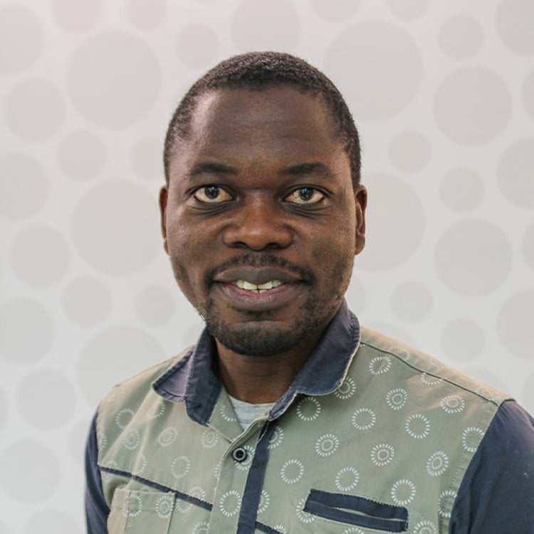

**Introduction**

In this informational interview, I had the opportunity to speak with Jailos Lubinda, an inspirational malaria researcher whose work has significantly contributed to our understanding of malaria epidemiology and control. His dedication to improving health outcomes in Africa has inspired many emerging researchers.

## Background

**Tell us about your background and what led you to pursue a career in malaria research.**

Jailos shared that his journey began with a keen interest in biology and public health. After completing his undergraduate studies in Biomedical Sciences, he pursued a Master’s in Public Health, focusing on infectious diseases. He found his passion in malaria research, motivated by the burden of the disease in sub-Saharan Africa.

## Research Focus

**What is your current research focus?**

Jailos is currently working on malaria transmission dynamics and interventions to reduce the incidence of malaria. He is particularly interested in the role of vector control and the impact of climate change on malaria transmission.

## Impactful Publications

**Can you tell us about some of your most impactful publications?**

Jailos highlighted several key publications that have influenced the field:

1. [Impact of Climate Variability on Malaria Transmission in Africa](https://www.sciencedirect.com/science/article/pii/S0962822319302782)
2. [The Role of Insecticide-treated Nets in Malaria Prevention](https://www.ncbi.nlm.nih.gov/pmc/articles/PMC7381380/)
3. Assessing the Effectiveness of Indoor Residual Spraying in Malaria Control

## Advice for Emerging Researchers

**What advice do you have for early career researchers?**

Jailos emphasized the importance of networking and collaboration in research. He encourages emerging researchers to engage with their communities and seek mentorship from experienced professionals. Additionally, he advises focusing on the practical applications of research findings to ensure that the work contributes to real-world solutions.

## Conclusion

This interview with Jailos Lubinda highlights the vital role of dedication and passion in advancing malaria research. His insights serve as a guide for emerging researchers aiming to make a meaningful impact in the field.